# HW2: exploration

Exploring Los Angeles County crimes data from 2020-2024

Author

Rosemary Juarez

Published

February 28, 2024

```r
# setting my chunk options
knitr::opts_chunk$set(echo = TRUE, message = FALSE, warning = FALSE)
```

## HW 3 overview:

For HW 3, i plan to go over option 2, which is creating an info-graphic using data I chose and displaying three different charts.

My question for this project is: **What is the general crime statistics in LA County?**

My question changed from the previous question I had, so now my question is much more broad. The reason it is broad is for one reason:

I’m still looking for what story angle I want to go with, whether its a focus on teen stats, weapon stats, or victim stats. I’m still undecided, so I’m hoping that by HW 4, I will have decided on an angle for storytelling.

Previously, my worries were that i didnt have enough numerical variables. I have since realized that it is okay, as my personal goal of this project is to explore and reveal what story i can uncover from this dataset.

for the variables I plan on using, It will be victim sex/age/race, weapon description, crime description, area name(city), and date. Those 7 variables should give me enough data to uncover multiple stories from here.

So far, the graphs i produced for this data set is bar charts and pie charts. Using primarily tidyverse and ggplot2, I created three bar charts and two pie charts. all the bar charts are counts of either weapon description, crime description, or gun-usage description. I calculated that a hand help gun is the most common gun to use in crimes. Fun fact: it looks like a gun, so hopefully i can polish it up by HW 4 to have that gun-like effect. For my pie charts, I decided to create rings to represent handcuffs. I explore both the race count and area name count to create my pie chart. I have found that Hispanics and 77th street in downtown LA have the most crime reports.

I’m still debating whether to change one of my two charts into a bar chart, as I want to have a bit more variance. However i would rather go with another option of adding another viz to my info-graphic, essentially creating 4 plots.

As for inspiration, I decided to go with two options:

- tidytuesday Dr. Who viz ([link](https://github.com/thedivtagguy/tidytuesday/tree/master/2023/week-48-nov-2023-doctor-who))
  - I really like that they imported images from another app to add to R. I use procreate(drawing app) a lot for my logo designs, so having the option to add some of my designs to my viz in R is a possibility i didnt consider before seeing this example
- UFO sightings viz ([link](https://github.com/doehm/tidytues?tab=readme-ov-file#week-25-ufo-sightings))
  - I really like how the theme really plays up with aliens, the dark night, and green-tech font. I think the way they managed to get the theme very well is what I hope to really encapsulate with my data viz.

As for my data viz design idea, I wanted to create a detective investigation pinboard, and have it look like it is a part of an investigation. A rough sketch is

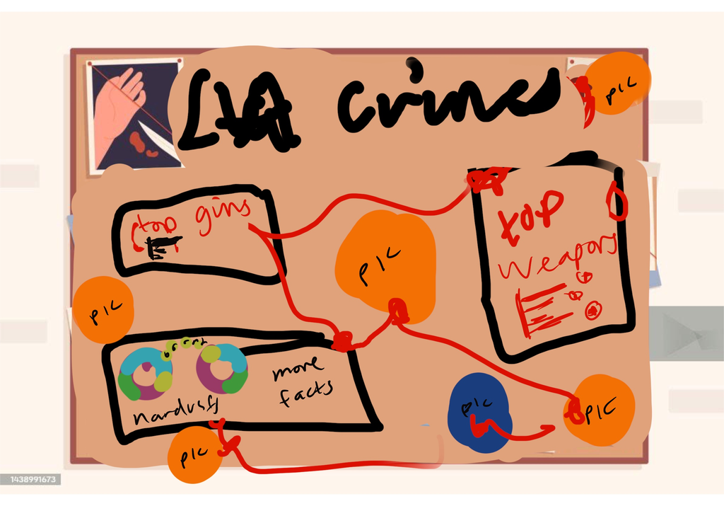

Challenges I encountered while creating my data viz is my rough draft not looking very good at all. Since I am currently drawing and exporting all the images and colors I will use for my viz from procreate (similar to the Dr. Who viz), My plots will look plain. Im hoping however that by HW 4, my info-graphic should be completed and look much better.

Packages I will be using for my project:

```r
#using these three packages
library(tidyverse) #main use for data wrangling
library(janitor) #helps with clean names for my variables
library(lubridate) #need this for my time data. Mostly for wrangling time data
library(stringr) #this helps with dealing with strings and characters in my data
library(magick) #this calls in images
library(gridExtra) #organizing my plot
library(patchwork) #organizing my plots even better
```

reading in my CSV on LA Crimes from 2020 - Present (Jan 18 2024)

```r
#reading in my data from my local computer
la_crimes <- read_csv("C:/Users/rosem/Documents/MEDS/Courses/EDS-240/HW/Juarez-eds240-HW4/data/Crime_Data_from_2020_to_Present_20240131.csv") %>%
  clean_names()
```

```r
#==============================================================
#                 data wrangling
# =============================================================

#will create a new column that describes the main 5 race categories. for reference:
#c(B - Black C - Chinese D - Cambodian F - Filipino G - Guamanian H - Hispanic/Latin/Mexican I - American Indian/Alaskan Native J - Japanese K - Korean L - Laotian O - Other P - Pacific Islander S - Samoan U - Hawaiian V - Vietnamese W - White X - Unknown Z - Asian Indian)

asian_countries <-  c('A', 'C', 'D', 'F',"L", 'J', 'K', 'V', 'Z')


# Define a named vector mapping the current categories to their full names
race_names <- c(
  "A" = "Asian",
  "B" = "Black",
  "W" = "White",
  "H" = "Hispanic",
  "I" = "Native American/Alaska",
  "P" = "pacific Islander"
)

#------------------------
#   regualar wrangling
# -----------------------

#creating a cleaned-up version of la_crimes. keeping the name so that i have less names to remember

la_crimes <- la_crimes %>%
  #removing zeros in the `vict_age` column, as 0, -1, and -2 indicated that no age was recorded.
  filter(vict_age > 0 ) %>%
  #I want to incllude all values for victim sex, however to first test out my plots, i want to view just male and female for simplicity
  #
  #
  filter(vict_sex %in% c('M', 'F')) %>%
  #Asian countries will be agreggated to one.



#-----------------------------
#   asian country aggregation
#-----------------------------

  #Asian countries will be aggregated to one. using case_when as it will help with selecting and reassigning asian countries to the letter "A" if the list of values i provided above are within asian_countries
  mutate(race_category = case_when(
    vict_descent %in% asian_countries ~ "A",
    TRUE ~ vict_descent  # Keep non-Asian races unchanged, as true will allow for the row that do not have an asian country to remain the same within the new "race_category" column.
  )) %>%

  #filter for the top 6 race categories
  filter(race_category %in% c('B', 'H', 'W', 'I', 'P', 'A')) %>%

# Rename the categories in the race column
  mutate(race = case_match(race_category, "B" ~ "Black",
                           "H" ~ "Hispanic",
                           "W"~ "White",
                           "I" ~ "Native American/Alaska",
                           "P" ~ "Pacific Islanders",
                           "A" ~ "asian"
                           ))
```

```r
#remove time component
la_crimes <- la_crimes %>%
  mutate(date_occ = as.Date(mdy_hms(date_occ)))

la_crimes <- la_crimes %>%
  mutate(month = month(date_occ))

la_crimes$month <- as.factor(la_crimes$month)
la_crimes$vict_age <- as.factor(la_crimes$vict_age)



la_crimes <- la_crimes %>%
   mutate(month = factor(month,
                                levels = c(1,2,3,4,5,6,7,8,9,10,11,12),
                                labels = c('January', 'February', 'March', 'April','May', 'June', 'July', 'August', 'September', 'October', 'November', 'December'))
)
```

```r
#====================================
#     new data frames for plotting
#====================================

#creating crime description
crime_desc <- la_crimes %>%
  group_by(crm_cd_desc) %>%
  summarise(count = n()) %>%
  arrange((desc(count)), .by_group = TRUE) %>%
  ungroup()


#crime description by sex
crime_desc_sex <- la_crimes %>%
  group_by(crm_cd_desc, vict_sex) %>%
  summarise(count = n()) %>%
  slice_max(order_by = count, n = 10) %>%
  group_by(crm_cd_desc) %>%
  ungroup()

#creating weapon description
weap_desc <- la_crimes %>%
  group_by(weapon_desc) %>%
  summarise(count = n()) %>%
  arrange((desc(count)), .by_group = TRUE) %>%
  na.omit() %>%

#filtering those that are unknown or not physical

  filter(!grepl("UNKNOWN", weapon_desc)) %>%
  filter(!grepl("OTHER", weapon_desc)) %>%
  filter(!grepl("VERBAL", weapon_desc))

#of those weapons, which ones are guns?
weap_gun <- weap_desc %>%
  filter(grepl("GUN", weapon_desc) | grepl("PISTOL", weapon_desc) | grepl("RIFLE", weapon_desc))
```

## Now we create our data viz

```r
top_10_bar <- crime_desc %>%
  slice(1:10)%>%
  ggplot( aes(x = fct_reorder(crm_cd_desc, count), y = count)) +
  geom_col(fill = "midnightblue") +
  coord_flip() +
  theme_classic()+
  labs(title = "top 10 crimes"

       ) +
  theme(axis.title.y = element_blank(),
        axis.line.y = element_blank(),
        axis.ticks.y = element_blank()


        )
```

```r
top_5_weap <- weap_desc %>%
  slice(1:5)%>%
  ggplot( aes(x = fct_reorder(weapon_desc, count), y = count)) +
  geom_col(fill = "midnightblue") +
  geom_text(aes(label = count), hjust = -.2) +
  coord_flip() +
  theme_classic()+
  labs(title = "Top 5 weapons"

       ) +
  scale_y_continuous(limits = c(0, 200000)) +
  theme(axis.title.y = element_blank(),
        axis.line.y = element_blank(),
        axis.ticks.y = element_blank()


        )
```

```r
library(showtext)
font_add_google(name = "Special Elite")
font_add_google(name = "Nosifer")

gun_bar <- weap_gun %>%
  slice(1:5)%>%
  ggplot( aes(x = fct_reorder(weapon_desc, count), y = count)) +
  geom_col(fill = "black") +
  geom_text(aes(label = count),family = "Special Elite", hjust = -.2, color = "red4", face = "bold", size = 5) +
  coord_flip() +
  theme_classic()+
  labs(title = "Crime Description with Gun Reports"

       ) +
  scale_y_continuous(limits = c(0, 20000)) +
  theme(axis.title.y = element_blank(),
        axis.text.x = element_blank(),
        axis.title.x = element_blank(),
        axis.line.y = element_blank(),
        axis.line.x = element_blank(),
        axis.ticks.y = element_blank(),
        axis.ticks.x = element_blank(),
        plot.title = element_text(family = "Nosifer",
                                  size = 15,
                                  color = "red4",
                                  face = "bold"),
        axis.text = element_text(family = "Special Elite",
                                 size = 12),
        axis.title = element_text(family = "Special Elite"),
        plot.margin = margin(.5,4,.5,.5, "cm")
        )  +


showtext_auto()
```

```r
library(ggforce)

race_pie <- la_crimes %>%
  count(race) %>%
  ggplot() +
  ggforce::geom_arc_bar(
    aes(x0 = 0, y0 = 0, r0 = 0.8, r = 1, amount = n, fill = race), #,explode = focus
   stat = "pie") +
  theme_void()+
  scale_fill_grey() +                           # (values = c("red", "green", "blue", "yellow", "orange", "purple")) +
  theme(
    legend.text = element_text(size=10, family = "Special Elite"),
    legend.title = element_text(face="bold", size=10, family = "Special Elite"),
    legend.key.size = unit(0.35, 'cm'),
    legend.position = c(0.6,0.45),
    legend.justification = c(1, 0),
    axis.title.x = element_blank(),
    axis.text.x = element_blank(),
    panel.grid.major.y = element_blank(),
    axis.line = element_blank()
    )
```

```r
area_pie <- la_crimes %>%
  count(area_name) %>%
  ggplot() +
  ggforce::geom_arc_bar(
    aes(x0 = 0, y0 = 0, r0 = 0.8, r = 1, amount = n, fill = area_name), #,explode = focus
   stat = "pie") +
  theme_void()+
  scale_fill_grey() +                           # (values = c("red", "green", "blue", "yellow", "orange", "purple")) +
  theme(
    legend.text = element_text(size=10, family = "Special Elite"),
    legend.title = element_text(face="bold", size=10, family = "Special Elite"),
    legend.key.size = unit(0.35, 'cm'),
    legend.position = c(0.6,0.45),
    legend.justification = c(1, 0),
    axis.title.x = element_blank(),
    axis.text.x = element_blank(),
    panel.grid.major.y = element_blank(),
    axis.line = element_blank()
    )
```

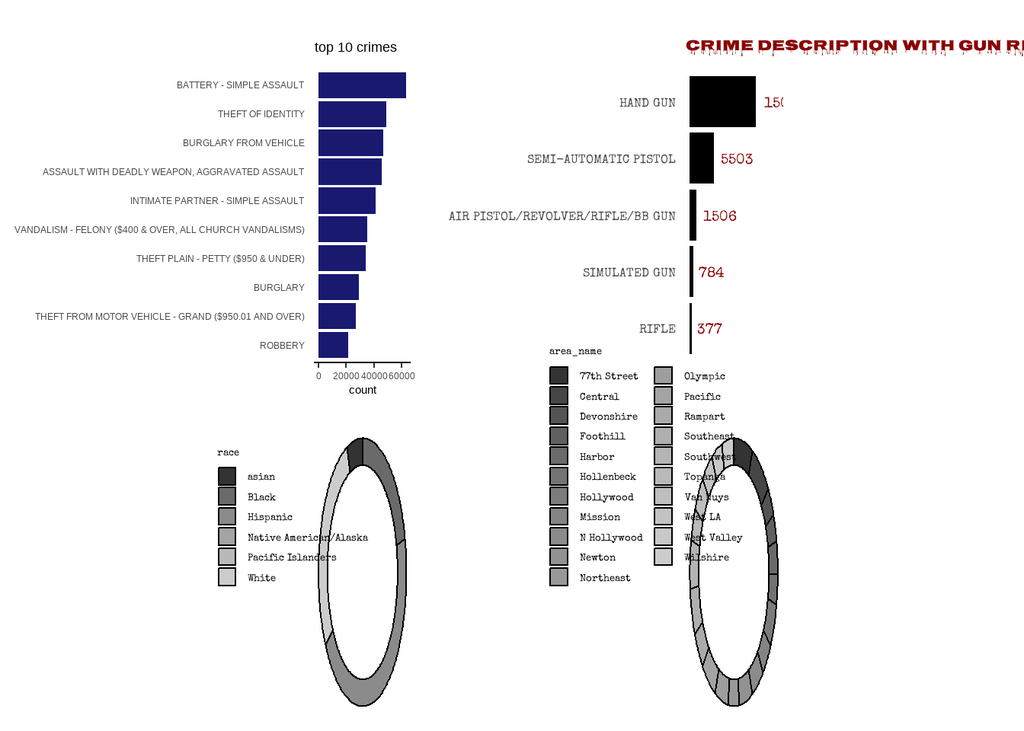

```r
#lets add my plots together now
top_10_bar + gun_bar +race_pie + area_pie
```